# Análise de internações de crianças por asma no Paraná

Análise de internações de crianças por asma no Paraná Séries Temporais - DES - UEM Arthur Rocha 2018-11-02

## Introdução

Esse trabalho foi feito com objetivo de ser uma avaliação parcial da segunda parte do conteúdo da disciplina de séries temporais, ministrada pela Prof. Dra. Eniuce Menezes de Souza. Tratam-se de dados retirados do DATASUS referentes a casos de internação por asma no Paraná de crianças com até 10 anos de idade.

## Leitura dos dados e manipulação

```r
#Pacotes
library(data.table) #Leitura de dados
library(dplyr)      #Manipulação
library(forecast)   #Séries temporais
library(astsa)      #Séries temporais
library(highcharter)#Gráficos interativos
library(ggplot2)    #Gráficos

## Dados brutos
dados_int_pr=fread("C:\\Users\\ASUS\\Desktop\\Uem\\4 ano\\Séries Temporais\\Trabalho\\intern_asma_pr_97_2017.csv",
                   encoding = "UTF-8")

## Série completa
dados_int_pr %>%
  group_by(idade_cat , ano, mes)%>%
  summarise(n=n()) %>%
  filter(idade_cat=="Infância") %>%
  as.data.frame()%>%
  select(n) -> serie.comp

## Série de "treinamento"
serie.comp[- c(226:237),1] %>%
  ts(start = 1998,frequency = 12) -> serie

## Série de teste (12 meses finais)
serie.comp[226:237,1]%>%
ts(start = c(2016,10),frequency = 12) -> teste
```

## Série temporal

É visível uma tendência negativa e uma variância não constante na série

```r
hchart(serie)%>%
  hc_add_theme(hc_theme_538(colors = c('orange', 'green', 'blue')))
```

[interactive chart not shown]

Diferenciando a série uma vez é possível retirar a tendência, mas fica evidente a inconstância da variância. Logo, é preciso aplicar uma transformação na série.

```r
serie %>%
  diff() %>%
  hchart()%>%
  hc_add_theme(hc_theme_538(colors = c('orange', 'green', 'blue')))
```

[interactive chart not shown]

Vê-se que parece razoável assumir uma variância constante após a transformação.

```r
serie %>%
  log() %>%
  diff() %>%
  hchart()%>%
  hc_add_theme(hc_theme_538(colors = c('orange', 'green', 'blue'))) %>%
  hc_add_series(diff(log(serie),differences = 2))
```

[interactive chart not shown]

Observando a FAC e FACp, é visível que existe uma sazonalidade na parte modelável por médias móveis.

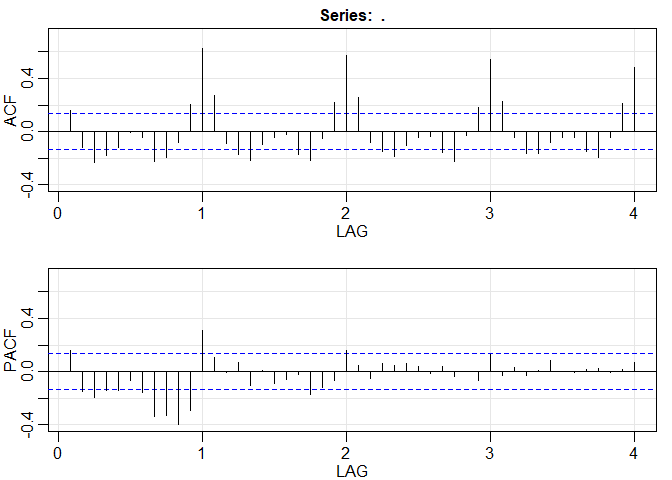

```
##         ACF  PACF
##  [1,]  0.16  0.16
##  [2,] -0.12 -0.15
##  [3,] -0.23 -0.19
##  [4,] -0.18 -0.14
##  [5,] -0.12 -0.14
##  [6,]  0.00 -0.06
##  [7,] -0.05 -0.16
##  [8,] -0.22 -0.34
##  [9,] -0.19 -0.33
## [10,] -0.08 -0.40
## [11,]  0.20 -0.29
## [12,]  0.63  0.31
## [13,]  0.27  0.11
## [14,] -0.09 -0.01
```

[output cut: 34 more lines]

```r
serie %>%
  log() %>%
  diff() %>%
  acf2(max.lag = 48)
```

## Modelagem

Como visto anteriormente, existe evidência de tendência, sazonalidade e variância não constante. Resolvidas as questões de tendência e variância por diferenciação e transformação log, faremos a identificação do modelo por partes, modelando primeiro a sazonalidade e depois os termos de médias móveis e autorregressivos.

- Modelo mais simples, considerando apenas a sazonalidade na parte de médias móveis.

Nota-se que o modelo não ficou bem ajustado pelas funções de autocorrelação e autocorrelaçã parcial. Dando indícios de que precisa de um parâmetro de médias móveis.

```r
serie.log= log(serie)

modelo1 = sarima(serie.log,p = 0,d=1,q=0,P=0,D = 1,Q = 1,S = 12)
```

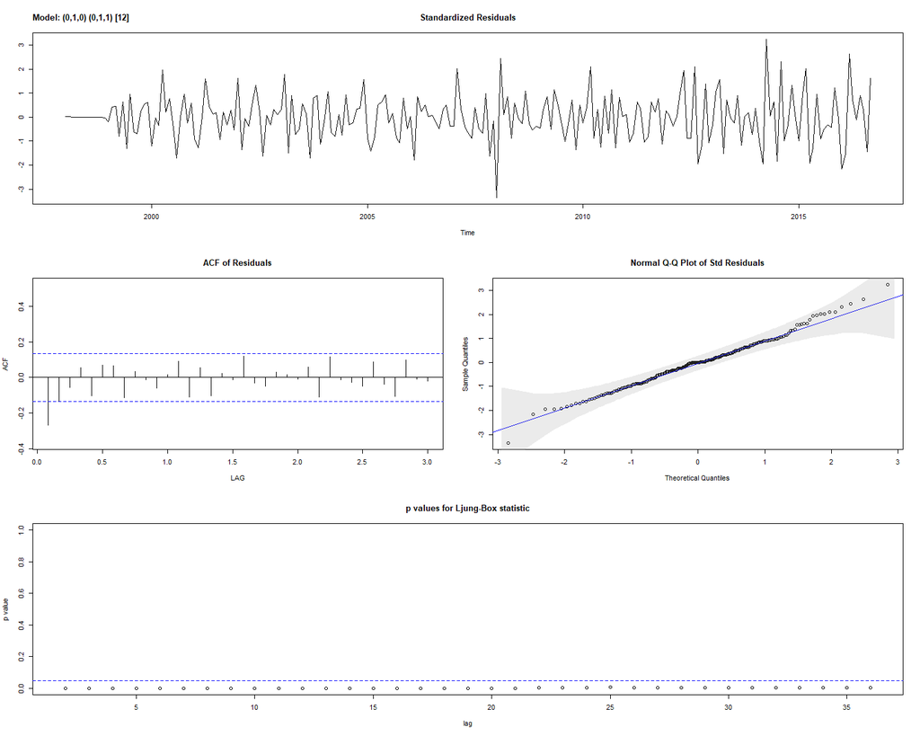

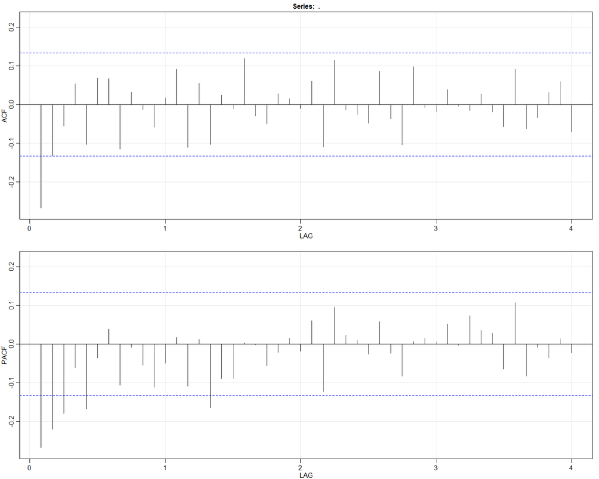

```
##         ACF  PACF
##  [1,] -0.27 -0.27
##  [2,] -0.13 -0.22
##  [3,] -0.06 -0.18
##  [4,]  0.05 -0.06
##  [5,] -0.10 -0.17
##  [6,]  0.07 -0.04
##  [7,]  0.07  0.04
##  [8,] -0.12 -0.11
##  [9,]  0.03 -0.01
## [10,] -0.01 -0.05
## [11,] -0.06 -0.11
## [12,]  0.02 -0.05
## [13,]  0.09  0.02
## [14,] -0.11 -0.11
```

[output cut: 34 more lines]

```r
modelo1$fit$residuals %>%
acf2()
```

- Incrementando o modelo

É possível ver que “sobram” autocorrelações aparentemente significantes, sendo que há indicatívos de que um termo de médias móveis é necessário dado o comportamento da FAC e FACp(decaimento exponencial), logo vamos adicioná-lo.

O modelo se apresentou melhor, mas não passando no critério de Ljung-Box.

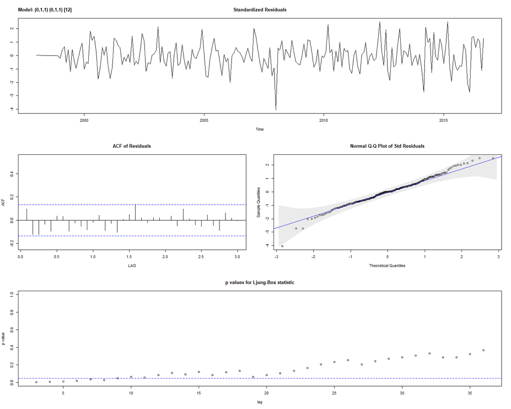

```
## $fit
##
## Call:
## stats::arima(x = xdata, order = c(p, d, q), seasonal = list(order = c(P, D,
##     Q), period = S), include.mean = !no.constant, optim.control = list(trace = trc,
##     REPORT = 1, reltol = tol))
##
## Coefficients:
##           ma1     sma1
##       -0.5030  -0.8476
## s.e.   0.0825   0.0561
##
## sigma^2 estimated as 0.01484:  log likelihood = 137.73,  aic = -269.46
##
## $degrees_of_freedom
## [1] 210
##
## $ttable
##      Estimate     SE  t.value p.value
## ma1   -0.5030 0.0825  -6.0949       0
## sma1  -0.8476 0.0561 -15.1012       0
##
## $AIC
## [1] -3.19246
##
## $AICc
## [1] -3.183088
##
## $BIC
## [1] -4.162094
```

```r
(modelo2 = sarima(serie.log,p = 0,d=1,q=1,P=0,D = 1,Q = 1,S = 12))
```

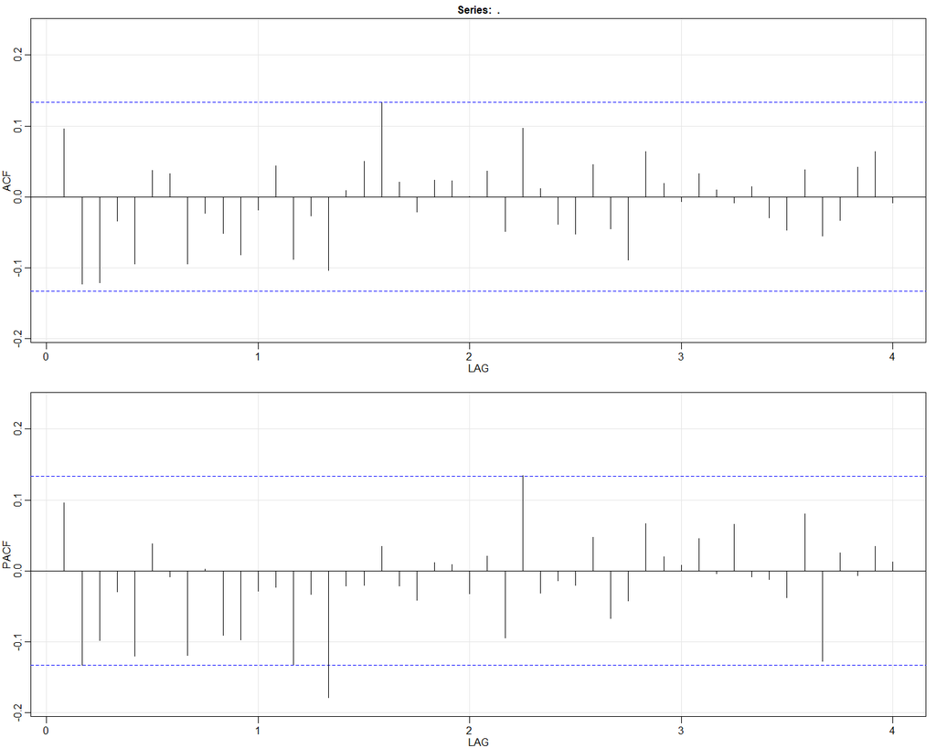

```
##         ACF  PACF
##  [1,]  0.10  0.10
##  [2,] -0.12 -0.13
##  [3,] -0.12 -0.10
##  [4,] -0.03 -0.03
##  [5,] -0.10 -0.12
##  [6,]  0.04  0.04
##  [7,]  0.03 -0.01
##  [8,] -0.10 -0.12
##  [9,] -0.02  0.00
## [10,] -0.05 -0.09
## [11,] -0.08 -0.10
## [12,] -0.02 -0.03
## [13,]  0.04 -0.02
## [14,] -0.09 -0.13
```

[output cut: 34 more lines]

```r
modelo2$fit$residuals %>%
acf2()
```

Adicionando um termo autorregressivo o problema foi resolvido.

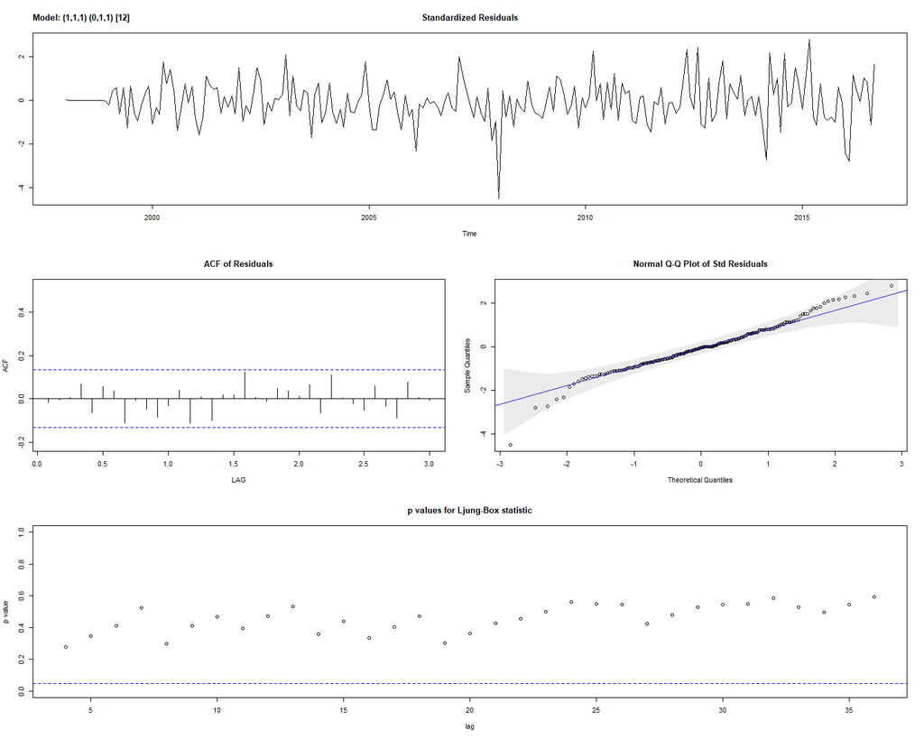

```
## $fit
##
## Call:
## stats::arima(x = xdata, order = c(p, d, q), seasonal = list(order = c(P, D,
##     Q), period = S), include.mean = !no.constant, optim.control = list(trace = trc,
##     REPORT = 1, reltol = tol))
##
## Coefficients:
##          ar1      ma1     sma1
##       0.4630  -0.8878  -0.8681
## s.e.  0.0851   0.0465   0.0612
##
## sigma^2 estimated as 0.01377:  log likelihood = 144.42,  aic = -280.83
##
## $degrees_of_freedom
## [1] 209
##
## $ttable
##      Estimate     SE  t.value p.value
## ar1    0.4630 0.0851   5.4392       0
## ma1   -0.8878 0.0465 -19.0828       0
## sma1  -0.8681 0.0612 -14.1809       0
##
## $AIC
## [1] -3.258266
##
## $AICc
## [1] -3.248569
##
## $BIC
## [1] -4.212718
```

```r
(modelo3 = sarima(serie.log,p = 1,d=1,q=1,P=0,D = 1,Q = 1,S = 12))
```

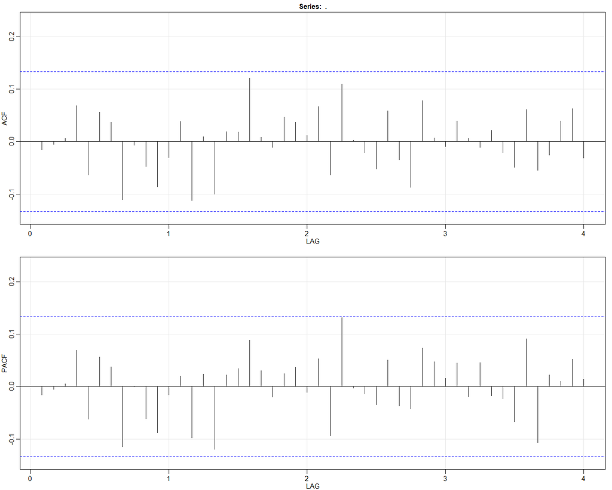

```
##         ACF  PACF
##  [1,] -0.02 -0.02
##  [2,] -0.01 -0.01
##  [3,]  0.01  0.01
##  [4,]  0.07  0.07
##  [5,] -0.06 -0.06
##  [6,]  0.06  0.06
##  [7,]  0.04  0.04
##  [8,] -0.11 -0.11
##  [9,] -0.01  0.00
## [10,] -0.05 -0.06
## [11,] -0.09 -0.09
## [12,] -0.03 -0.02
## [13,]  0.04  0.02
## [14,] -0.11 -0.10
```

[output cut: 34 more lines]

```r
modelo3$fit$residuals %>%
acf2()
```

- Modelo de suavização exponencial

A partir do comando `ets` do pacote `forecast`, chegou-se ao melhor modelo de suvização exponencial, com erro e sazonalidade multiplicativos e tendência aditiva.

```r
(modelo.ets = ets(serie))
```

```
## ETS(M,Ad,M)
##
## Call:
##  ets(y = serie)
##
##   Smoothing parameters:
##     alpha = 0.5189
##     beta  = 0.0025
##     gamma = 1e-04
##     phi   = 0.98
##
##   Initial states:
##     l = 1280.3205
##     b = -7.8619
##     s=0.8257 0.9206 0.9139 0.9616 1.0481 1.1496
##            1.3282 1.37 1.1761 1.0105 0.6335 0.6622
##
##   sigma:  0.1133
##
##      AIC     AICc      BIC
## 3122.686 3126.007 3184.176
```

- Modelo da função `auto.arima`

O pacote `forecast` também conta com a função `auto.arima`, que tenta achar qual o melhor modelo das classes arima / sarima para se ajustar à série. No caso, ajustou um ARIMA(2,1,3)(1,0,0)[12]. Esse modelo não teve os melhores resíduos, não passando no teste de Ljung-Box

```r
(modelo.auto = auto.arima(serie.log))
```

```
## Series: serie.log
## ARIMA(2,1,3)(1,0,0)[12]
##
## Coefficients:
##           ar1     ar2      ma1      ma2      ma3    sar1
##       -0.1766  0.3762  -0.1606  -0.5965  -0.1425  0.7374
## s.e.   0.1901  0.1354   0.2133   0.1308   0.1494  0.0516
##
## sigma^2 estimated as 0.02097:  log likelihood=113.25
## AIC=-212.5   AICc=-211.99   BIC=-188.62
```

```r
modelo.auto = sarima(serie,2,1,3,1,0,0,12) #Só para soltar o diagnóstico
```

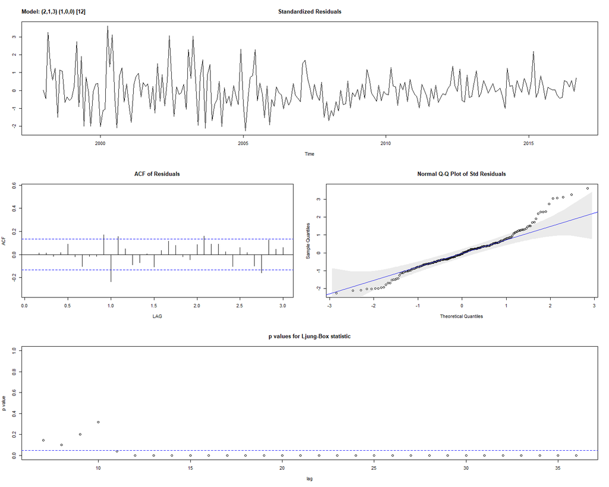

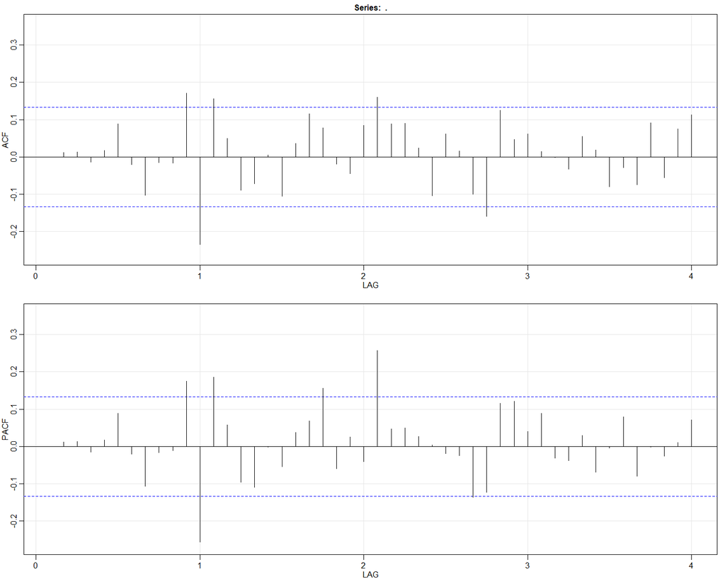

```
##         ACF  PACF
##  [1,]  0.00  0.00
##  [2,]  0.01  0.01
##  [3,]  0.01  0.01
##  [4,] -0.01 -0.01
##  [5,]  0.02  0.02
##  [6,]  0.09  0.09
##  [7,] -0.02 -0.02
##  [8,] -0.10 -0.11
##  [9,] -0.01 -0.02
## [10,] -0.02 -0.01
## [11,]  0.17  0.17
## [12,] -0.23 -0.26
## [13,]  0.16  0.19
## [14,]  0.05  0.06
```

[output cut: 34 more lines]

```r
modelo.auto$fit$residuals %>%
acf2()
```

## Previsão

Aqui são expostos os resultados das previsões dos modelos escolhidos.

- Modelo Sarima (1,1,1)(0,1,1)

```r
Arima(serie,order = c(1,1,1),seasonal = c(0,1,1),lambda = 0)%>%
forecast(h=12) -> mae.dina

hchart(mae.dina) %>%
  hc_add_series(teste,type = "scatter")%>%
  hc_add_theme(hc_theme_538(colors=c("orange",rgb(.1,.2,.2,.4),rgb(.2,.2,.2,.4),rgb(.1,.2,.2,.4))))
```

[interactive chart not shown]

- Modelo de suavização exponencial

```r
mae.dina2 = forecast(modelo.ets,h=12)

hchart(mae.dina2) %>%
  hc_add_series(teste,type = "scatter")%>%
    hc_add_theme(hc_theme_538(colors=c("orange",rgb(.1,.2,.2,.4),
                                      rgb(.2,.2,.2,.4),rgb(.1,.2,.2,.4))))
```

[interactive chart not shown]

- Modelo auto.arima

```r
Arima(serie,order = c(2,1,3),seasonal = c(1,0,0),lambda = 0)%>%
forecast(h=12) -> mae.dina3

hchart(mae.dina3) %>%
  hc_add_series(teste,type = "scatter")%>%
  hc_add_theme(hc_theme_538(colors=c("orange",rgb(.1,.2,.2,.4),
                                      rgb(.2,.2,.2,.4),rgb(.1,.2,.2,.4))))
```

[interactive chart not shown]

- Todos juntos

```r
hchart(mae.dina,type="line")%>%
  hc_add_series(mae.dina2,type="line")%>%
  hc_add_series(mae.dina3,type="line")%>%
  hc_add_series(teste,type = "scatter")%>%
  hc_add_theme(hc_theme_538())
```

[interactive chart not shown]

## Comparação entre modelos

As comparações entre os modelos serão feitos a partir das medições de erro e U de Theil.

```r
library(DescTools)

data.frame(modelo=c("Modelo teste","Modelo ets","Modelo auto"),
           U_Theil = c(TheilU(as.numeric(teste),
                              as.numeric(mae.dina$mean)),
                       TheilU(as.numeric(teste),
                              as.numeric(mae.dina2$mean)),
                       TheilU(as.numeric(teste),
                              as.numeric(mae.dina3$mean))
                       )
           ) %>%
  cbind(rbind(accuracy(mae.dina,teste)[2,],
      accuracy(mae.dina2,teste)[2,],
      accuracy(mae.dina3,teste)[2,]))%>%
  knitr::kable()
```

| modelo | U_Theil | ME | RMSE | MAE | MPE | MAPE | MASE | ACF1 | Theil’s U |
| --- | --- | --- | --- | --- | --- | --- | --- | --- | --- |
| Modelo teste | 0.1746054 | 22.692722 | 41.53419 | 32.58642 | 6.789246 | 14.43959 | 0.3425917 | 0.3035327 | 0.6159188 |
| Modelo ets | 0.1448237 | 0.519101 | 34.44988 | 25.18298 | -3.585650 | 12.93594 | 0.2647569 | 0.2917720 | 0.4772927 |
| Modelo auto | 0.1932803 | 20.944934 | 45.97648 | 35.73738 | 5.787037 | 15.86047 | 0.3757188 | 0.5396463 | 0.7108506 |